# Problem set 4: Movie budgets

S470/670

Spring 2018

Read the data and load packages:

```r
movie_budgets = read.table("movie_budgets.txt", header=TRUE)
library(ggplot2)
library(broom)
```

Add a logged budget variable for convenience:

```r
movie_budgets = data.frame(movie_budgets, log10_budget = log10(movie_budgets$budget))
```

Do a rough check for linearity:

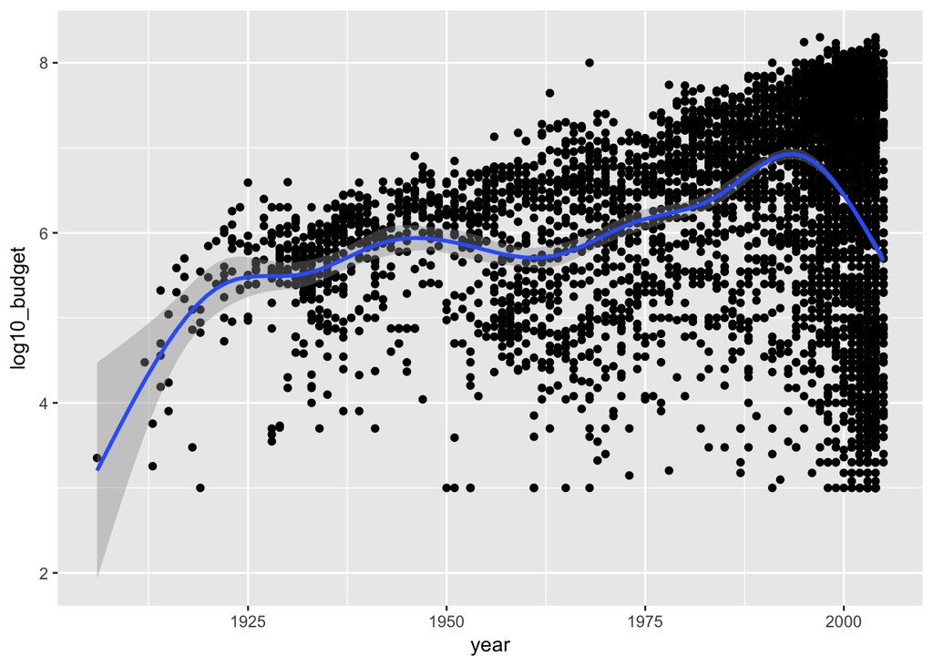

```r
ggplot(movie_budgets, aes(x=year, y=log10_budget)) + geom_point() + geom_smooth()
```

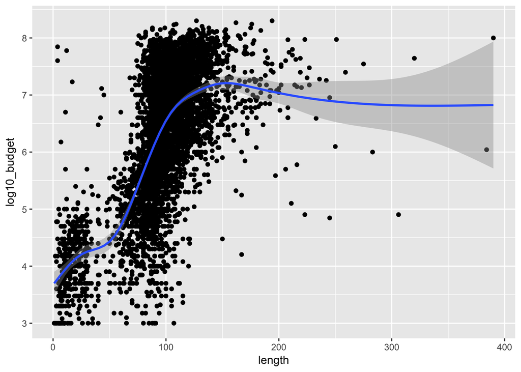

```r
ggplot(movie_budgets, aes(x=length, y=log10_budget)) + geom_point() + geom_smooth()
```

Logged budget is pretty obviously nonlinear in year. It looks nonlinear in length as well, though this is in large part because of a small proportion of extremely long movies (over 150 minutes.) Nevertheless, it’ll be safer to fit a loess model rather than a linear model. The data doesn’t look “nice” (there are outliers all over the place) so it’ll be safer to do a robust fit using `family = "symmetric"`.

Do we need an interaction? It’s a judgment call – including the interaction necessarily improves the fit, but increases the complexity and complicates interpretation. In this case our model isn’t too complicated, so IMHO we might as well throw it in.

What about the `span` of the loess fit? Keep reducing it until you get residuals that look randomly scattered around zero in all relevant plots, making sure that the final fit you end up with is reasonably smooth. I found 0.15 worked well.

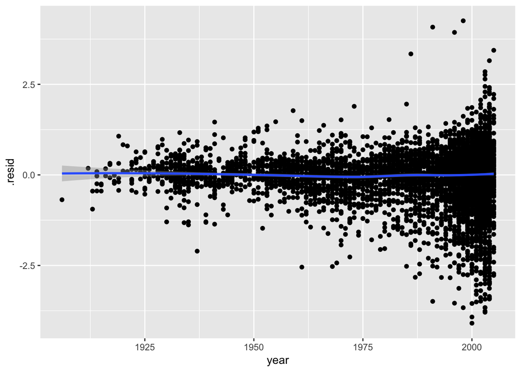

```r
budget.lo = loess(log10_budget ~ year * length, span = 0.15, family = "symmetric", data = movie_budgets)
budget.lo.df = augment(budget.lo)
ggplot(budget.lo.df, aes(x=year, y=.resid)) + geom_point() + geom_smooth(method = "loess", method.args = list(family = "symmetric"))
```

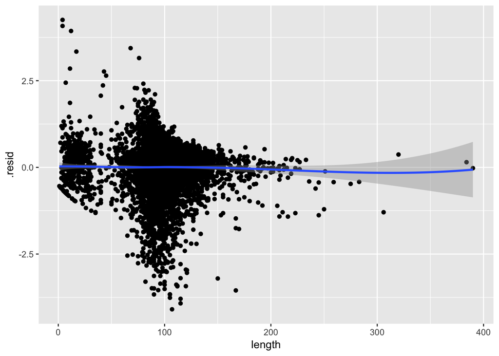

```r
ggplot(budget.lo.df, aes(x=length, y=.resid)) + geom_point() + geom_smooth(method = "loess", method.args = list(family = "symmetric"))
```

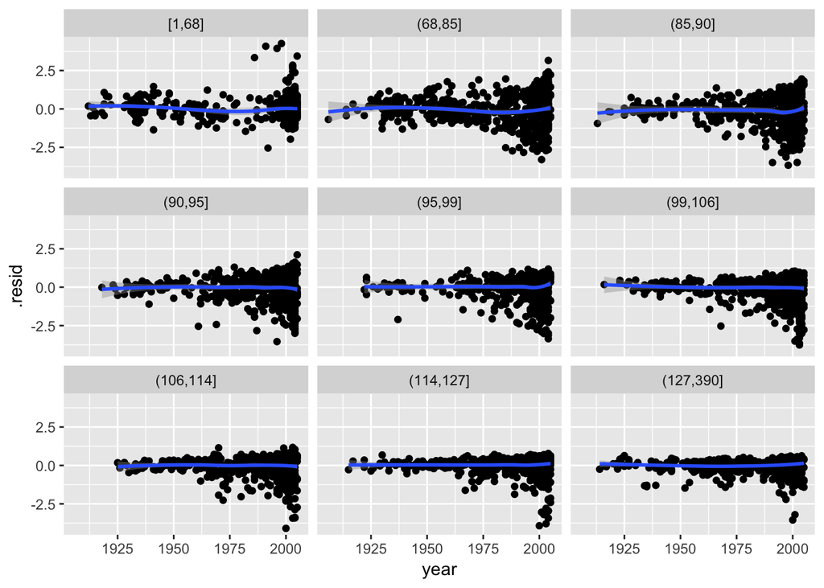

```r
ggplot(budget.lo.df, aes(x=year, y=.resid)) + geom_point() + facet_wrap(~cut_number(length, n=9), ncol=3) + geom_smooth(method.args = list(family = "symmetric"))
```

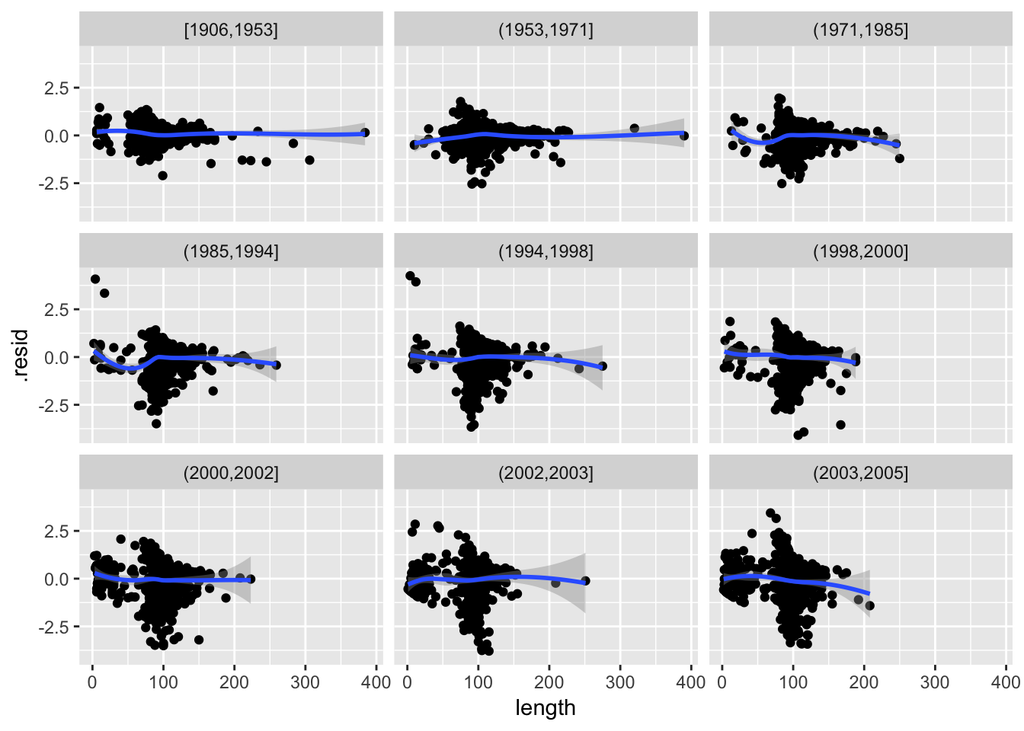

```r
ggplot(budget.lo.df, aes(x=length, y=.resid)) + geom_point() + facet_wrap(~cut_number(year, n=9), ncol=3) + geom_smooth(method.args = list(family = "symmetric"))
```

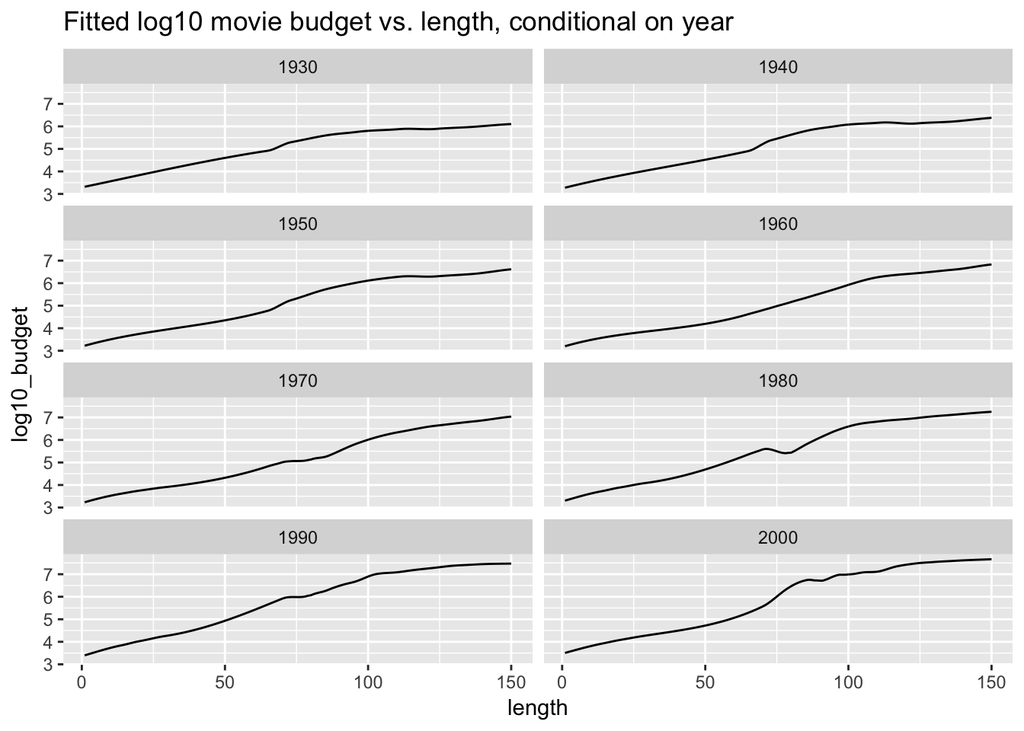

```r
movie.grid = expand.grid(length=1:150, year=seq(1930,2000,10))
movie.predict = predict(budget.lo, newdata=movie.grid)
ggplot(data.frame(movie.grid, log10_budget=as.vector(movie.predict)), aes(x=length, y=log10_budget)) + geom_line() + facet_wrap(~year, ncol=2) + labs(title="Fitted log10 movie budget vs. length, conditional on year")
```

The increase in log budget with length does seems to be sub-linear (which makes sense since budget is logged; you wouldn’t expect making your movie $x$ minutes longer would make it $y$ times more expensive. A transformation of length would’ve been sensible here.) Inflation in movie budgets is more pronounced for full-length movies than for shorts.

Let’s draw a contour plot because I don’t really like wireframes:

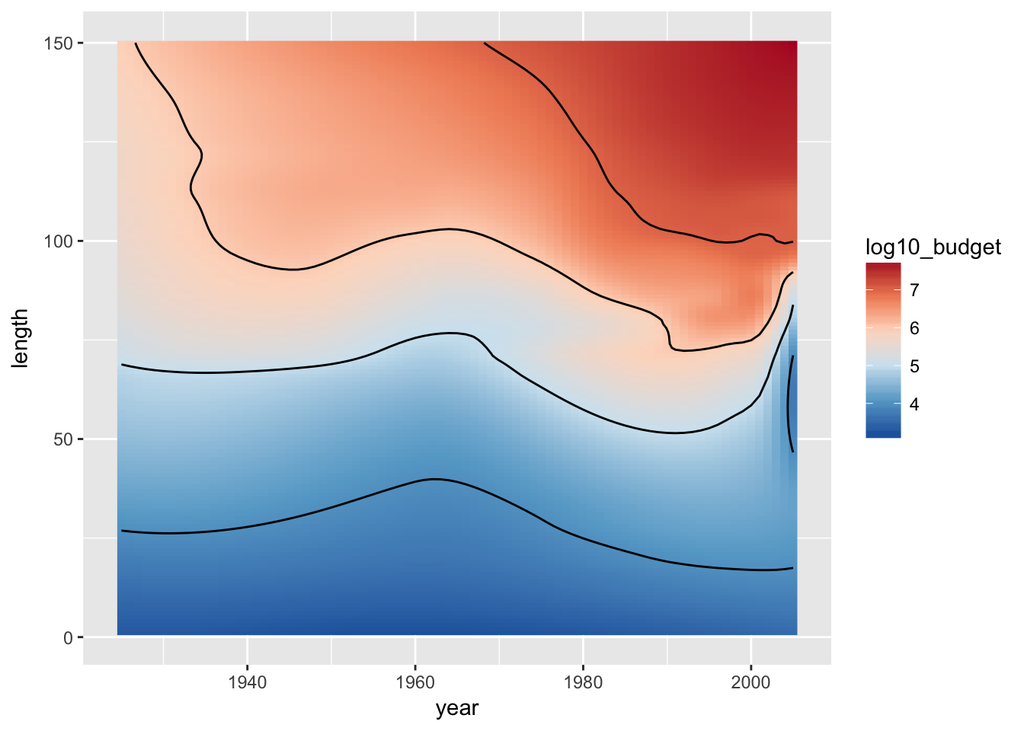

```r
movie.contour.grid = expand.grid(length=1:150, year=1925:2005)
movie.contour.predict = predict(budget.lo, newdata=movie.contour.grid)
ggplot(data.frame(movie.contour.grid, log10_budget=as.vector(movie.contour.predict)), aes(x=year, y=length, z=log10_budget, fill=log10_budget)) + geom_raster()  + geom_contour(breaks = 4:7, color="black") + scale_fill_distiller(palette="RdBu")
```

We can interpret the contours as how much movie a dollar amount “buys”. So a million dollars (the “6” contour) used to get you a 150-minute epic, but now barely buys a 90 minute cheapie. The uptick in contours/decrease in budgets in recent years is probably just selection bias: recent low-budget movies are more likely to be in the data set than old low-budget movies.